# Visualization of NIfTI Images

## Again we read in the data

```r
t1 = neurobase::readnii("training01_01_t1.nii.gz")
```

## Density of an Image

Let’s do a marginal density of the values:

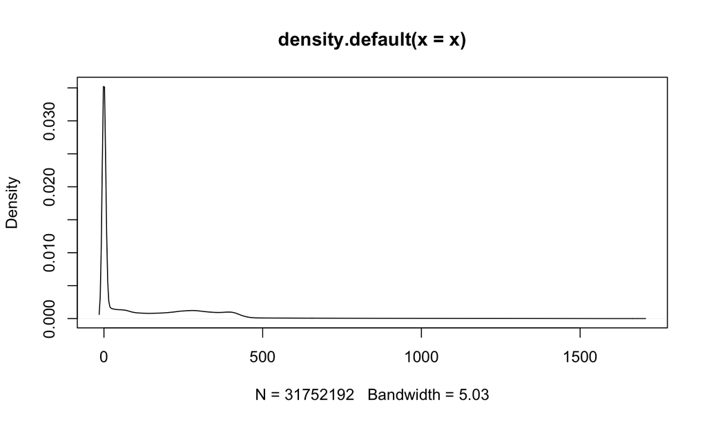

```r
plot(density(t1)) # large spike at 0
```

## Density with a mask

You can also pass in a mask to most standard functions:

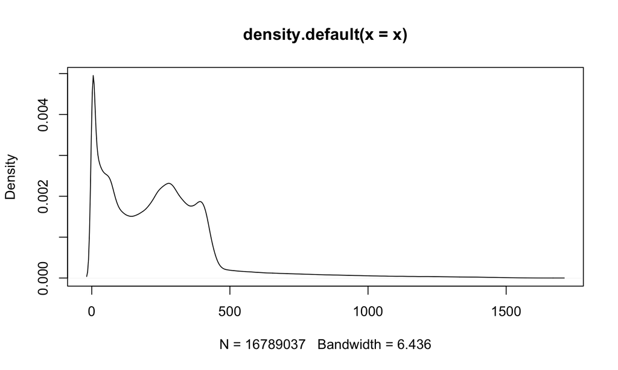

```r
plot(density(t1, mask = t1 > 0))
```

## Similarly: a Histogram

Note the high intensities:

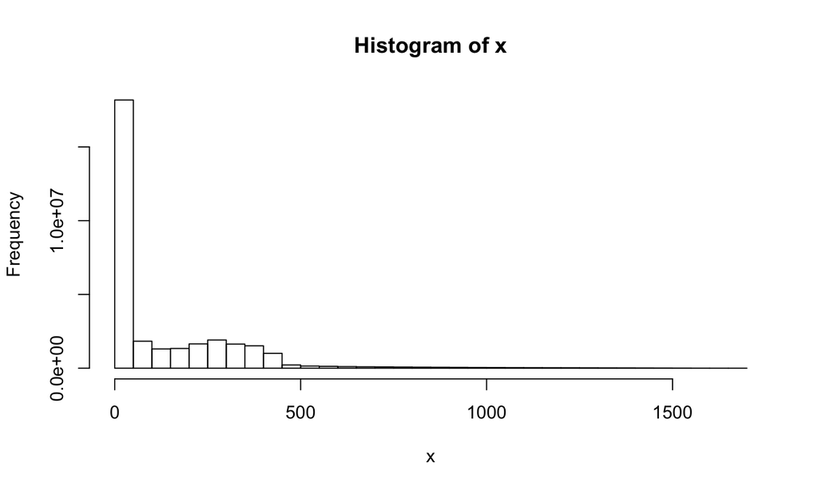

```r
hist(t1)
```

## Orthographic view with additions

The `neurobase::ortho2` function displays nifti objects in 3 different planes.

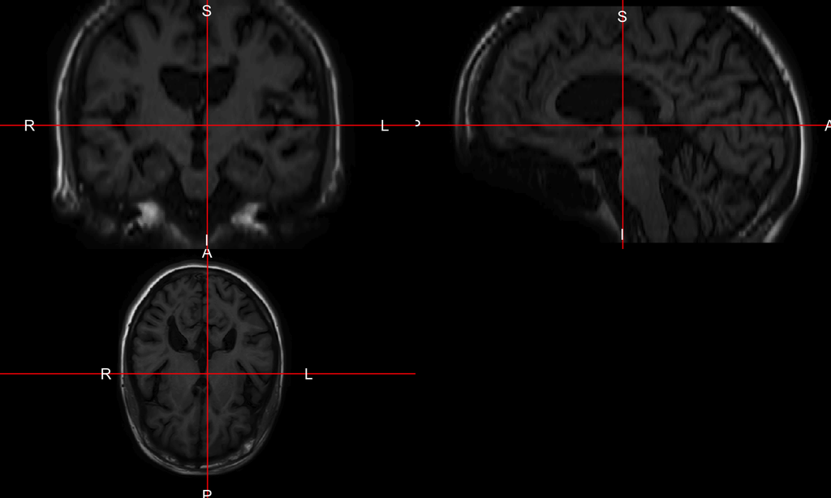

```r
neurobase::ortho2(t1)
```

## Brightening up the image

We see a dark image; a this single large value affects how values are mapped. The function `robust_window` calculates Winsorizes an image, by default the 0 (min) and 99.9th quantile, and sets values outside of this range to that quantile (97.5th below).

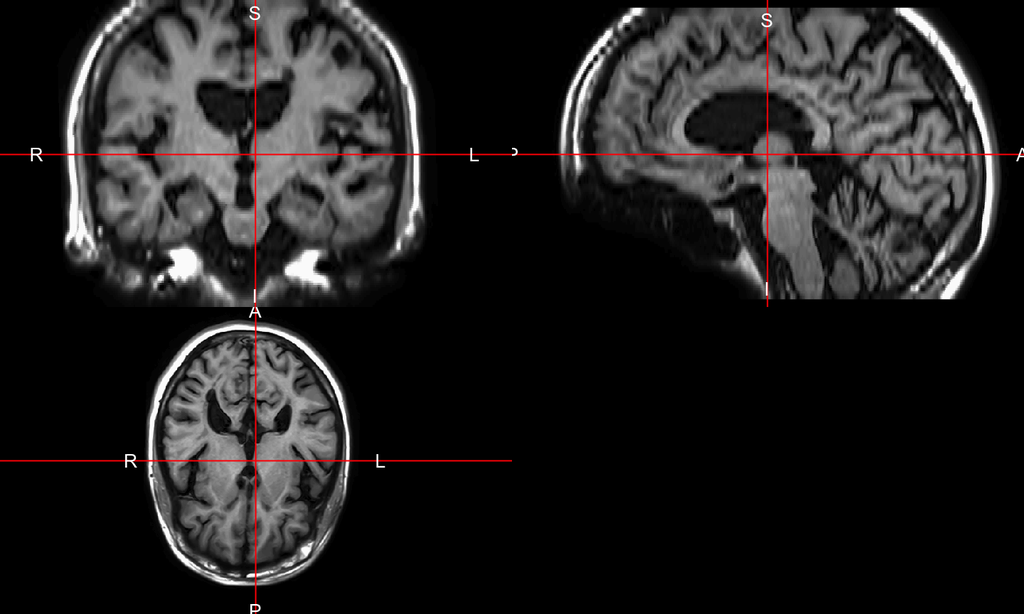

```r
ortho2(robust_window(t1, probs = c(0, 0.975)))
```

## Robust Density

Note the x-axis:

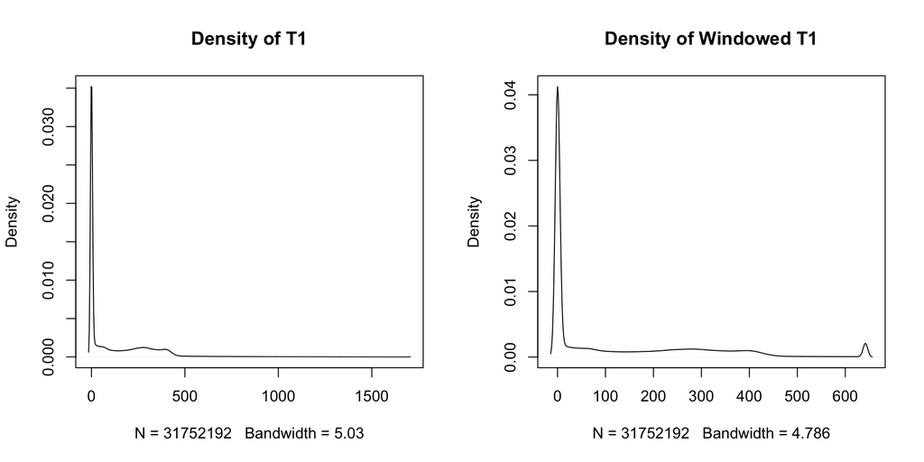

## Overlaying images in `ortho2`

For the rest of the slides we will use the robust `t1` for plotting

Here we plot the T1 and a mask of values over \(300\):

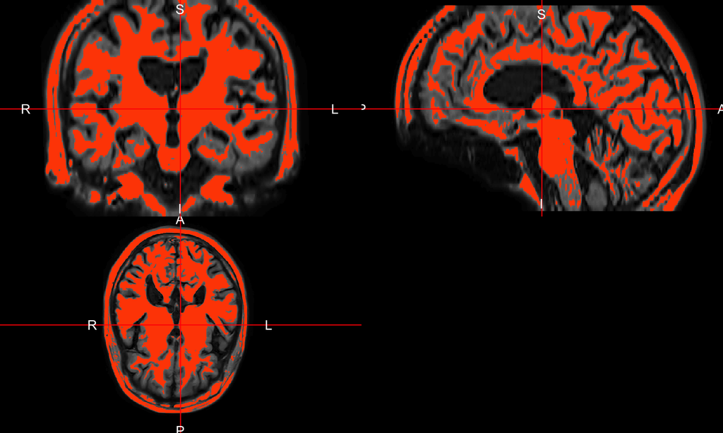

```r
ortho2(t1, y = t1 > 300)
```

## Double orthographic view

Sometimes you would like to represent 2 images side by side, of the same dimensions and orientation of course (useful for checking registration), use `double_ortho`

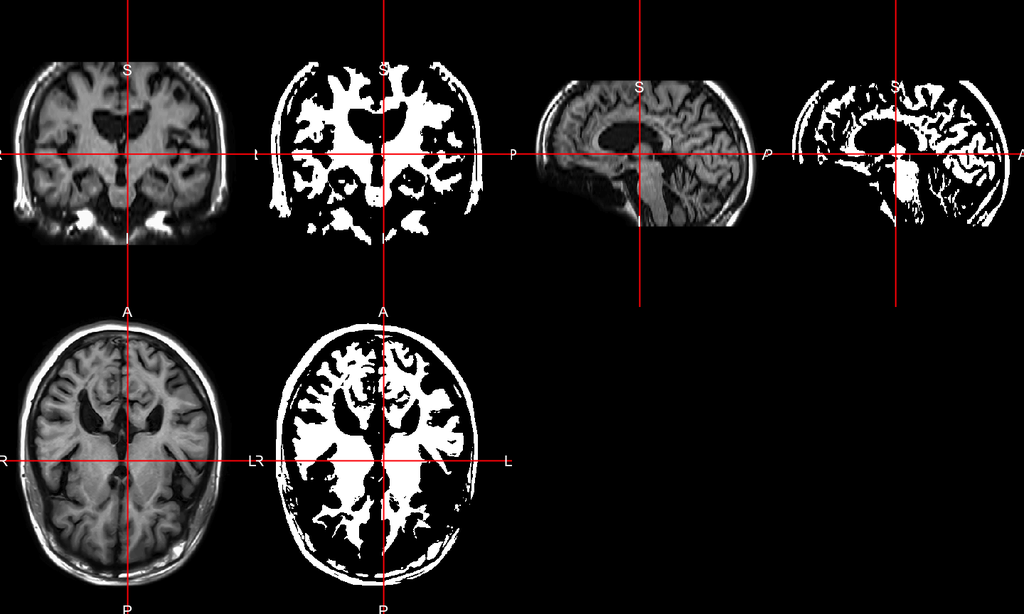

```r
double_ortho(t1, y = t1 > 300, col.y = "white")
```

## Lightbox: view all slices

The `oro.nifti::image` function shows a lightbox view, all slices of an image:

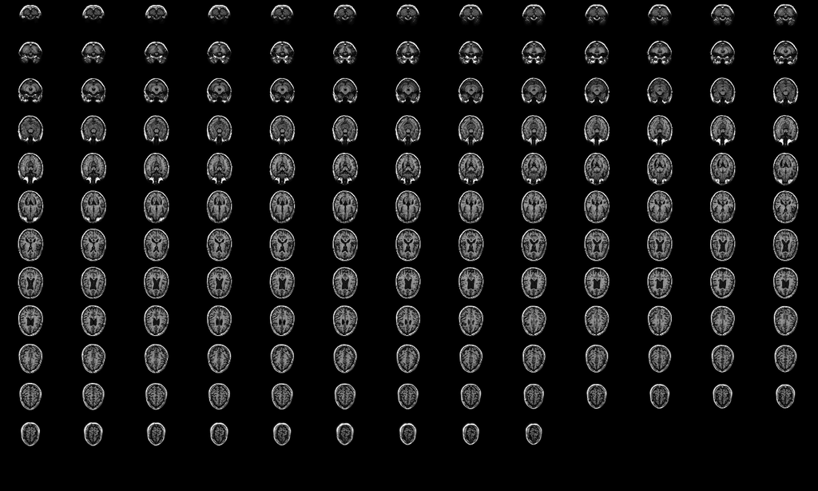

```r
image(t1, useRaster = TRUE) # look at average brightness over each slice
```

## Viewing specific slices

The `slice` function can plot individual slices:

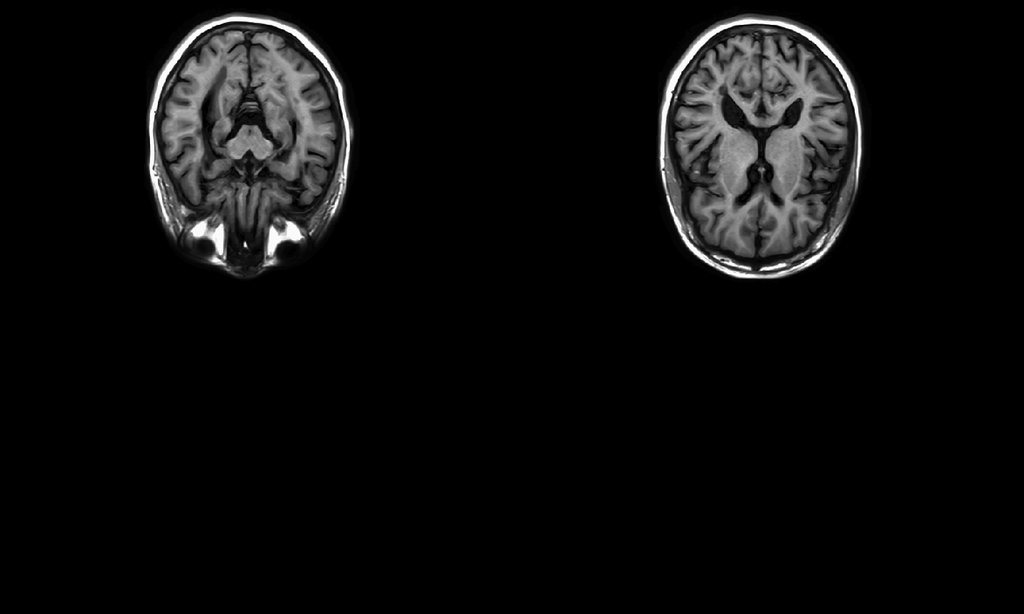

```r
oro.nifti::slice(t1, z = c(60, 80))
```

## Different Planes

We can specify `z` the same way but change the `plane` to be different to get a different slice of the brain (could also do coronal):

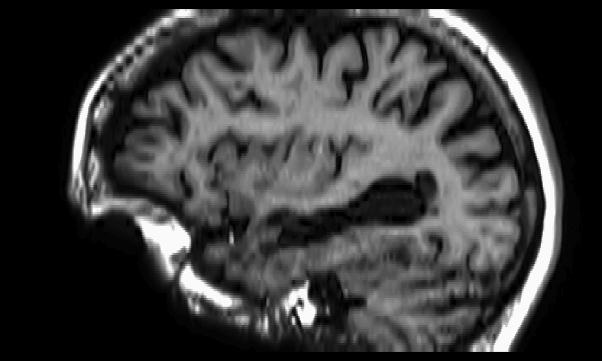

```r
oro.nifti::slice(t1, z = 125, plane = "sagittal")
```

## Overlaying slices

We can also overlay one slice of an image upon another using the `oro.nifti::slice_overlay` function.

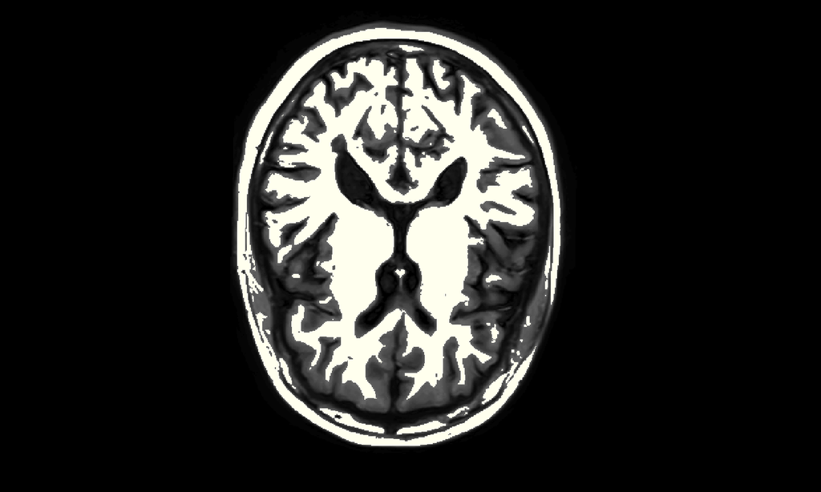

```r
slice_overlay(t1, y = t1 > 300, z = 80)
```

## Smoothing an Image (not extensively covered)

If you want to do 3D Gaussian smoothing, the `extrantsr::smooth_image` is helpful:

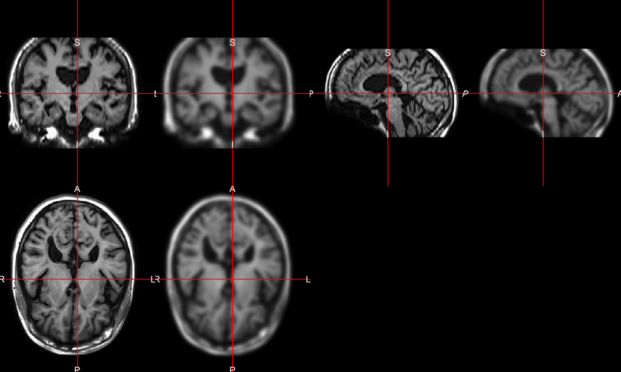

```r
library(extrantsr)
sm_img = smooth_image(t1, sigma = 2)
double_ortho(t1, sm_img)
```

## Conclusions

- `ortho2` - show orthographic images (and with overlays)
- `image` - shows multiple slices of an image
- `slice` - shows only specified slices
- `slice_overlay` - similar to `image` but with an overlay
- `double_ortho` - similar to `ortho2` but side-by-side
- `robust_window` - good for setting high values to not so high

## Website

http://johnmuschelli.com/imaging_in_r